# Part I - (Prosper Loan Data Exploration)

by (Sobia Arshad) Introduction:

This dataset is a financial daatset which is related to Loans,borrowers,Lenders interest rates etc.Prosper is a california based company which specialises in loans with a low interest rate to the borroweres.In this dataset, we are using the data from the Posper to analyse it and trying to find the pattern in the Prosper data and communicate our data findings through Data exploration.

```python
# import all packages and set plots to be embedded inline
import numpy as np
import pandas as pd
import matplotlib.pyplot as plt
import seaborn as sb


%matplotlib inline
```

# Loading Dataset and describing it's Properties:

```python
# load in the dataset into a pandas dataframe, print statistics
loandata = pd.read_csv('prosperLoanData.csv')
loandata.head(5)
```

|  | ListingKey | ListingNumber | ListingCreationDate | CreditGrade | Term | LoanStatus | ClosedDate | BorrowerAPR | BorrowerRate | LenderYield | ... | LP_ServiceFees | LP_CollectionFees | LP_GrossPrincipalLoss | LP_NetPrincipalLoss | LP_NonPrincipalRecoverypayments | PercentFunded | Recommendations | InvestmentFromFriendsCount | InvestmentFromFriendsAmount | Investors |
| --- | --- | --- | --- | --- | --- | --- | --- | --- | --- | --- | --- | --- | --- | --- | --- | --- | --- | --- | --- | --- | --- |
| 0 | 1021339766868145413AB3B | 193129 | 2007-08-26 19:09:29.263000000 | C | 36 | Completed | 2009-08-14 00:00:00 | 0.16516 | 0.1580 | 0.1380 | ... | -133.18 | 0.0 | 0.0 | 0.0 | 0.0 | 1.0 | 0 | 0 | 0.0 | 258 |
| 1 | 10273602499503308B223C1 | 1209647 | 2014-02-27 08:28:07.900000000 | NaN | 36 | Current | NaN | 0.12016 | 0.0920 | 0.0820 | ... | 0.00 | 0.0 | 0.0 | 0.0 | 0.0 | 1.0 | 0 | 0 | 0.0 | 1 |
| 2 | 0EE9337825851032864889A | 81716 | 2007-01-05 15:00:47.090000000 | HR | 36 | Completed | 2009-12-17 00:00:00 | 0.28269 | 0.2750 | 0.2400 | ... | -24.20 | 0.0 | 0.0 | 0.0 | 0.0 | 1.0 | 0 | 0 | 0.0 | 41 |
| 3 | 0EF5356002482715299901A | 658116 | 2012-10-22 11:02:35.010000000 | NaN | 36 | Current | NaN | 0.12528 | 0.0974 | 0.0874 | ... | -108.01 | 0.0 | 0.0 | 0.0 | 0.0 | 1.0 | 0 | 0 | 0.0 | 158 |
| 4 | 0F023589499656230C5E3E2 | 909464 | 2013-09-14 18:38:39.097000000 | NaN | 36 | Current | NaN | 0.24614 | 0.2085 | 0.1985 | ... | -60.27 | 0.0 | 0.0 | 0.0 | 0.0 | 1.0 | 0 | 0 | 0.0 | 20 |

5 rows × 81 columns

```python
loandata.info()
```

```
<class 'pandas.core.frame.DataFrame'>
RangeIndex: 113937 entries, 0 to 113936
Data columns (total 81 columns):
 #   Column                               Non-Null Count   Dtype
---  ------                               --------------   -----
 0   ListingKey                           113937 non-null  object
 1   ListingNumber                        113937 non-null  int64
 2   ListingCreationDate                  113937 non-null  object
 3   CreditGrade                          28953 non-null   object
 4   Term                                 113937 non-null  int64
 5   LoanStatus                           113937 non-null  object
 6   ClosedDate                           55089 non-null   object
 7   BorrowerAPR                          113912 non-null  float64
 8   BorrowerRate                         113937 non-null  float64
 9   LenderYield                          113937 non-null  float64
```

[output cut: 73 more lines]

```python
print(loandata.shape)
print(loandata.dtypes)
```

```
(113937, 81)
ListingKey                      object
ListingNumber                    int64
ListingCreationDate             object
CreditGrade                     object
Term                             int64
                                ...
PercentFunded                  float64
Recommendations                  int64
InvestmentFromFriendsCount       int64
InvestmentFromFriendsAmount    float64
Investors                        int64
Length: 81, dtype: object
```

```python
# descriptive statistics for numeric variables
print(loandata.describe())
```

```
       ListingNumber           Term    BorrowerAPR   BorrowerRate  \
count   1.139370e+05  113937.000000  113912.000000  113937.000000
mean    6.278857e+05      40.830248       0.218828       0.192764
std     3.280762e+05      10.436212       0.080364       0.074818
min     4.000000e+00      12.000000       0.006530       0.000000
25%     4.009190e+05      36.000000       0.156290       0.134000
50%     6.005540e+05      36.000000       0.209760       0.184000
75%     8.926340e+05      36.000000       0.283810       0.250000
max     1.255725e+06      60.000000       0.512290       0.497500

         LenderYield  EstimatedEffectiveYield  EstimatedLoss  EstimatedReturn  \
count  113937.000000             84853.000000   84853.000000     84853.000000
mean        0.182701                 0.168661       0.080306         0.096068
std         0.074516                 0.068467       0.046764         0.030403
min        -0.010000                -0.182700       0.004900        -0.182700
25%         0.124200                 0.115670       0.042400         0.074080
50%         0.173000                 0.161500       0.072400         0.091700
75%         0.240000                 0.224300       0.112000         0.116600
max         0.492500                 0.319900       0.366000         0.283700

       ProsperRating (numeric)  ProsperScore  ...  LP_ServiceFees  \
count             84853.000000  84853.000000  ...   113937.000000
mean                  4.072243      5.950067  ...      -54.725641
std                   1.673227      2.376501  ...       60.675425
min                   1.000000      1.000000  ...     -664.870000
25%                   3.000000      4.000000  ...      -73.180000
50%                   4.000000      6.000000  ...      -34.440000
75%                   5.000000      8.000000  ...      -13.920000
max                   7.000000     11.000000  ...       32.060000

       LP_CollectionFees  LP_GrossPrincipalLoss  LP_NetPrincipalLoss  \
count      113937.000000          113937.000000        113937.000000
mean          -14.242698             700.446342           681.420499
std           109.232758            2388.513831          2357.167068
min         -9274.750000             -94.200000          -954.550000
25%             0.000000               0.000000             0.000000
50%             0.000000               0.000000             0.000000
75%             0.000000               0.000000             0.000000
max             0.000000           25000.000000         25000.000000

       LP_NonPrincipalRecoverypayments  PercentFunded  Recommendations  \
count                    113937.000000  113937.000000    113937.000000
mean                         25.142686       0.998584         0.048027
std                         275.657937       0.017919         0.332353
min                           0.000000       0.700000         0.000000
25%                           0.000000       1.000000         0.000000
50%                           0.000000       1.000000         0.000000
75%                           0.000000       1.000000         0.000000
max                       21117.900000       1.012500        39.000000

       InvestmentFromFriendsCount  InvestmentFromFriendsAmount      Investors
count               113937.000000                113937.000000  113937.000000
mean                     0.023460                    16.550751      80.475228
std                      0.232412                   294.545422     103.239020
min                      0.000000                     0.000000       1.000000
25%                      0.000000                     0.000000       2.000000
50%                      0.000000                     0.000000      44.000000
75%                      0.000000                     0.000000     115.000000
max                     33.000000                 25000.000000    1189.000000

[8 rows x 61 columns]
```

```python
loandata.sample(10)
```

|  | ListingKey | ListingNumber | ListingCreationDate | CreditGrade | Term | LoanStatus | ClosedDate | BorrowerAPR | BorrowerRate | LenderYield | ... | LP_ServiceFees | LP_CollectionFees | LP_GrossPrincipalLoss | LP_NetPrincipalLoss | LP_NonPrincipalRecoverypayments | PercentFunded | Recommendations | InvestmentFromFriendsCount | InvestmentFromFriendsAmount | Investors |
| --- | --- | --- | --- | --- | --- | --- | --- | --- | --- | --- | --- | --- | --- | --- | --- | --- | --- | --- | --- | --- | --- |
| 22858 | AEC53381292189073D28E87 | 91855 | 2007-02-01 10:10:14.110000000 | E | 36 | Defaulted | 2007-11-13 00:00:00 | 0.24716 | 0.2300 | 0.2050 | ... | -1.33 | 0.00 | 1000.57 | 1000.57 | 0.0 | 1.0 | 0 | 0 | 0.0 | 30 |
| 11031 | 15C33595249061079353E11 | 999601 | 2013-11-16 09:46:23.853000000 | NaN | 36 | Current | NaN | 0.12274 | 0.0949 | 0.0849 | ... | -49.17 | 0.00 | 0.00 | 0.00 | 0.0 | 1.0 | 0 | 0 | 0.0 | 1 |
| 9791 | 4B5A35702245738207C9EB1 | 709053 | 2013-02-04 18:44:36.830000000 | NaN | 60 | Current | NaN | 0.25359 | 0.2284 | 0.2184 | ... | -94.55 | 0.00 | 0.00 | 0.00 | 0.0 | 1.0 | 0 | 0 | 0.0 | 108 |
| 39112 | 43BD3569930296314647E4F | 711526 | 2013-02-09 02:04:02.933000000 | NaN | 36 | Completed | 2013-11-15 00:00:00 | 0.33286 | 0.2932 | 0.2832 | ... | -23.41 | 0.00 | 0.00 | 0.00 | 0.0 | 1.0 | 0 | 0 | 0.0 | 44 |
| 65941 | DAB535083822981809E7BFE | 494582 | 2011-02-17 17:52:07.813000000 | NaN | 12 | Completed | 2011-04-26 00:00:00 | 0.13972 | 0.0820 | 0.0720 | ... | -5.26 | 0.00 | 0.00 | 0.00 | 0.0 | 1.0 | 0 | 0 | 0.0 | 53 |
| 58398 | F30A3595069089430A4DC8A | 1007995 | 2013-11-21 10:15:21.273000000 | NaN | 36 | Current | NaN | 0.18990 | 0.1535 | 0.1435 | ... | -4.83 | 0.00 | 0.00 | 0.00 | 0.0 | 1.0 | 0 | 0 | 0.0 | 1 |
| 77133 | 4632359098892647720A8F4 | 922877 | 2013-09-23 16:41:52.850000000 | NaN | 60 | Current | NaN | 0.26333 | 0.2379 | 0.2279 | ... | -60.97 | 0.00 | 0.00 | 0.00 | 0.0 | 1.0 | 0 | 0 | 0.0 | 37 |
| 29833 | 94BA3423822271349B6C96C | 356643 | 2008-06-24 20:39:34.813000000 | AA | 36 | Completed | 2010-07-29 00:00:00 | 0.11696 | 0.1100 | 0.1000 | ... | -143.97 | 0.00 | 0.00 | 0.00 | 0.0 | 1.0 | 0 | 0 | 0.0 | 274 |
| 113509 | F67A3573054360608109553 | 725046 | 2013-03-08 11:16:10.963000000 | NaN | 60 | Past Due (16-30 days) | NaN | 0.31293 | 0.2862 | 0.2762 | ... | -3.35 | -43.41 | 0.00 | 0.00 | 0.0 | 1.0 | 0 | 0 | 0.0 | 25 |
| 96150 | EACC35788146665609F339A | 773475 | 2013-05-08 12:50:39.963000000 | NaN | 36 | Current | NaN | 0.19645 | 0.1599 | 0.1499 | ... | -28.02 | 0.00 | 0.00 | 0.00 | 0.0 | 1.0 | 0 | 0 | 0.0 | 1 |

10 rows × 81 columns

# What is the structure of your dataset?

In this dataset we have a total of 113,937 loans with 81 attributes/columns for them most of which are float and values objects.

### What is/are the main feature(s) of interest in your dataset?

APR is a simple percentage term used to express the numerical amount paid by an individual or entity yearly for the privilege of borrowing money.

I am mostly interested in predicting what features are best for predicting cost of credit as a yearly rate which is Borrowers Annual percentage Rate(APR) for the loan?

Does Term affects APR?

Is APR higher than Interest rate?

Another thing that can be explored for this Loan system is how monthlyIncome of a person effects his loan amount.If he is earning more than Is HE/SHE able to apply for more loan amount?

We will also see that how ProsperRating is affecting other variables of interest in this loan system

There are so many attributes in this dataset but for data analysis and exploration purpose I will take into account few main features which are as follows:

Term: The length of the loan expressed in months. LoanStatus: BorrowerRate 'ProsperRating (Alpha)', 'ListingCategory (numeric)', 'EmploymentStatus', 'StatedMonthlyIncome', 'TotalProsperLoans', 'LoanOriginalAmount', 'LoanOriginationDate', 'Recommendations', 'Investors'

### What features in the dataset do you think will help support your investigation into your feature(s) of interest?

Loan amount can have an impact on determing APR so we have to take it into account during our data exploration phases. Monthly income will also be explored during this exploration and will see its effects too. Also Prosper rating will be taken into account. Loanstatus is of prime importance in this dataset as it has values like(Cancelled,charged off,Completetd,Current,defaulted,final payement in progress,pastDue)which shows as if how many loans were approved and who many were cancelled. Another important attribute is 'Term' which specifies the length of loan given by this company 'Prosper'. The Borrower's interest rate for this loan(BorrowerRate)is also of significant importance in this dataset. In our analysis we will also consider how Loan Amount will effect staus of Loan to be approved.

Before starting our Exploration we would like to take sample of the data with attributes that we are considering in this anlysis.

```python
chosen_columns =  [
    'Term', 'LoanStatus', 'BorrowerRate','BorrowerAPR', 'ProsperRating (Alpha)', 'ListingCategory (numeric)', 'EmploymentStatus',
    'DelinquenciesLast7Years', 'StatedMonthlyIncome', 'TotalProsperLoans', 'LoanOriginalAmount',
    'LoanOriginationDate', 'Recommendations', 'Investors'
]
```

```python
chosen_loandata = loandata[chosen_columns]
```

```python
chosen_loandata.sample(10)
```

|  | Term | LoanStatus | BorrowerRate | BorrowerAPR | ProsperRating (Alpha) | ListingCategory (numeric) | EmploymentStatus | DelinquenciesLast7Years | StatedMonthlyIncome | TotalProsperLoans | LoanOriginalAmount | LoanOriginationDate | Recommendations | Investors |
| --- | --- | --- | --- | --- | --- | --- | --- | --- | --- | --- | --- | --- | --- | --- |
| 57796 | 60 | Current | 0.2489 | 0.27462 | C | 1 | Employed | 0.0 | 3312.500000 | NaN | 15000 | 2012-06-07 00:00:00 | 0 | 28 |
| 43240 | 60 | Current | 0.2962 | 0.32321 | E | 7 | Employed | 0.0 | 1300.000000 | NaN | 4000 | 2013-02-01 00:00:00 | 0 | 31 |
| 31289 | 36 | Completed | 0.1029 | 0.12400 | A | 1 | Full-time | 0.0 | 9187.500000 | 1.0 | 13500 | 2011-07-29 00:00:00 | 0 | 120 |
| 113890 | 36 | Completed | 0.1475 | 0.15462 | NaN | 0 | Full-time | 0.0 | 3333.333333 | NaN | 10000 | 2007-08-14 00:00:00 | 0 | 281 |
| 94795 | 36 | Current | 0.1685 | 0.20562 | C | 1 | Employed | 0.0 | 11000.000000 | NaN | 10000 | 2014-02-14 00:00:00 | 0 | 24 |
| 11835 | 36 | Current | 0.1089 | 0.13697 | A | 1 | Employed | 0.0 | 52500.000000 | NaN | 15000 | 2012-07-31 00:00:00 | 0 | 200 |
| 25186 | 36 | Current | 0.2399 | 0.27467 | D | 3 | Self-employed | 0.0 | 2708.333333 | 1.0 | 7500 | 2011-08-25 00:00:00 | 0 | 52 |
| 21654 | 36 | Current | 0.2148 | 0.25259 | C | 1 | Employed | 0.0 | 5416.666667 | NaN | 15000 | 2012-06-21 00:00:00 | 0 | 30 |
| 38663 | 36 | Current | 0.1725 | 0.20933 | C | 2 | Employed | 15.0 | 5358.166667 | NaN | 12500 | 2013-12-16 00:00:00 | 0 | 178 |
| 78690 | 12 | Defaulted | 0.2669 | 0.35843 | E | 3 | Employed | 18.0 | 12500.000000 | NaN | 6815 | 2011-04-12 00:00:00 | 0 | 129 |

```python
chosen_loandata.info()
```

```
<class 'pandas.core.frame.DataFrame'>
RangeIndex: 113937 entries, 0 to 113936
Data columns (total 14 columns):
 #   Column                     Non-Null Count   Dtype
---  ------                     --------------   -----
 0   Term                       113937 non-null  int64
 1   LoanStatus                 113937 non-null  object
 2   BorrowerRate               113937 non-null  float64
 3   BorrowerAPR                113912 non-null  float64
 4   ProsperRating (Alpha)      84853 non-null   object
 5   ListingCategory (numeric)  113937 non-null  int64
 6   EmploymentStatus           111682 non-null  object
 7   DelinquenciesLast7Years    112947 non-null  float64
 8   StatedMonthlyIncome        113937 non-null  float64
 9   TotalProsperLoans          22085 non-null   float64
 10  LoanOriginalAmount         113937 non-null  int64
 11  LoanOriginationDate        113937 non-null  object
 12  Recommendations            113937 non-null  int64
 13  Investors                  113937 non-null  int64
dtypes: float64(5), int64(5), object(4)
memory usage: 12.2+ MB
```

Since ProsperRating(Alpha)was applicable after july 2009 and we have alot of missing valuess in this data column so let's remove them.

```python
chosen_loandata = chosen_loandata.dropna(subset=['ProsperRating (Alpha)']).reset_index()
```

```python
chosen_loandata['TotalProsperLoans'] = chosen_loandata['TotalProsperLoans'].fillna(0)
```

Convert LoanOriginationDate to datetime.

```python
chosen_loandata['LoanOriginationDate'] = pd.to_datetime(chosen_loandata['LoanOriginationDate'])
```

```python
chosen_loandata.info()
```

```
<class 'pandas.core.frame.DataFrame'>
RangeIndex: 84853 entries, 0 to 84852
Data columns (total 15 columns):
 #   Column                     Non-Null Count  Dtype
---  ------                     --------------  -----
 0   index                      84853 non-null  int64
 1   Term                       84853 non-null  int64
 2   LoanStatus                 84853 non-null  object
 3   BorrowerRate               84853 non-null  float64
 4   BorrowerAPR                84853 non-null  float64
 5   ProsperRating (Alpha)      84853 non-null  object
 6   ListingCategory (numeric)  84853 non-null  int64
 7   EmploymentStatus           84853 non-null  object
 8   DelinquenciesLast7Years    84853 non-null  float64
 9   StatedMonthlyIncome        84853 non-null  float64
 10  TotalProsperLoans          84853 non-null  float64
 11  LoanOriginalAmount         84853 non-null  int64
 12  LoanOriginationDate        84853 non-null  datetime64[ns]
 13  Recommendations            84853 non-null  int64
 14  Investors                  84853 non-null  int64
dtypes: datetime64[ns](1), float64(5), int64(6), object(3)
memory usage: 9.7+ MB
```

# Borrower APR(The Borrower's Annual percentage Rate)

Annual Percentage Rate (APR) is the cost of credit as a yearly rate. The APR is a disclosure mandated by the Truth in Lending Act of 1968. It is designed to accurately disclose the true cost of credit and provide a standard basis of comparison for the costs of credit.

I will start looking at the variable of main interest here which is Borrowers APR.Let us visualise it by Histogram and see the results:

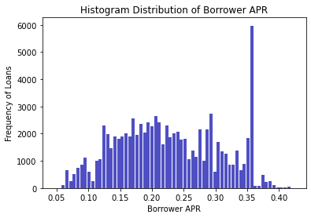

```python
n, bins, patches = plt.hist(data = chosen_loandata, x = 'BorrowerAPR',  bins='auto', color='#0504aa',
                            alpha=0.7, rwidth=0.85)
plt.xlabel('Borrower APR')
plt.ylabel('Frequency of Loans')
plt.title('Histogram Distribution of Borrower APR')
```

Analysis:

```python
# Check loans with APR greater than 0.43
chosen_loandata[chosen_loandata.BorrowerAPR>0.43]
```

|  | index | Term | LoanStatus | BorrowerRate | BorrowerAPR | ProsperRating (Alpha) | ListingCategory (numeric) | EmploymentStatus | DelinquenciesLast7Years | StatedMonthlyIncome | TotalProsperLoans | LoanOriginalAmount | LoanOriginationDate | Recommendations | Investors |
| --- | --- | --- | --- | --- | --- | --- | --- | --- | --- | --- | --- | --- | --- | --- | --- |

# Loan Term :(For How long most of the people are taking loans)

We will use Seaborn function Countplot() to Show the counts of observations in each categorical bin using bars.

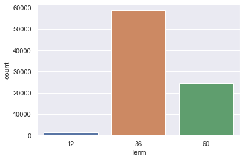

```python
sb.set_theme(style="darkgrid")

sb.countplot(data = chosen_loandata, x = 'Term');
```

Analysis: Based on above represenattion we can infer that most of the people in this data set are taking loan for 36 months i.e for a period of 3 years and very few percentage of people are taking for a period of 1 year.

# LoanStatus(The current status of the Loan)

In this dataset there are variuos status for Loan like completed,Defaulted,Cancelled,Chargedoff etc.

```python
chosen_loandata.sample(5)
```

|  | index | Term | LoanStatus | BorrowerRate | BorrowerAPR | ProsperRating (Alpha) | ListingCategory (numeric) | EmploymentStatus | DelinquenciesLast7Years | StatedMonthlyIncome | TotalProsperLoans | LoanOriginalAmount | LoanOriginationDate | Recommendations | Investors |
| --- | --- | --- | --- | --- | --- | --- | --- | --- | --- | --- | --- | --- | --- | --- | --- |
| 74038 | 99368 | 36 | Completed | 0.0839 | 0.09736 | AA | 1 | Employed | 0.0 | 8750.000000 | 0.0 | 20000 | 2012-09-25 | 0 | 146 |
| 72900 | 97860 | 60 | Current | 0.1299 | 0.15271 | A | 1 | Employed | 0.0 | 4666.666667 | 0.0 | 15000 | 2013-10-24 | 0 | 1 |
| 15191 | 20405 | 60 | Current | 0.2432 | 0.26877 | D | 1 | Employed | 1.0 | 8666.666667 | 0.0 | 10000 | 2013-07-08 | 0 | 15 |
| 20805 | 27952 | 36 | Completed | 0.3494 | 0.38661 | HR | 1 | Full-time | 26.0 | 5833.333333 | 1.0 | 6500 | 2010-12-21 | 0 | 51 |
| 45172 | 60669 | 36 | Current | 0.2099 | 0.24758 | C | 6 | Other | 49.0 | 100.666667 | 0.0 | 3000 | 2012-09-28 | 0 | 36 |

```python
a_count=chosen_loandata[chosen_loandata["LoanStatus"]=='FinalPaymentInProgress'].count()["index"]

print (a_count)
```

```
205
```

```python
b_count=chosen_loandata[chosen_loandata["LoanStatus"]=='Completed'].count()["index"]

print (b_count)
```

```
19664
```

```python
r_count=chosen_loandata[chosen_loandata["LoanStatus"]=='Defaulted'].count()["index"]

print (r_count)
```

```
1005
```

```python
rb_count=chosen_loandata[chosen_loandata["LoanStatus"]=='Current'].count()["index"]

print (rb_count)
```

```
56576
```

```python
rch_count=chosen_loandata[chosen_loandata["LoanStatus"]=='Chargedoff'].count()["index"]

print (rch_count)
```

```
5336
```

```python
rchc_count=chosen_loandata[chosen_loandata["LoanStatus"]=='Cancelled'].count()["index"]

print (rchc_count)
```

```
0
```

```python
rc_count=chosen_loandata[chosen_loandata["LoanStatus"]=='PastDue'].count()["index"]

print (rc_count)
```

```
0
```

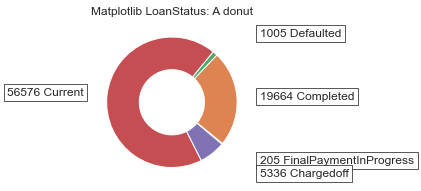

```python
fig, ax = plt.subplots(figsize=(6, 3), subplot_kw=dict(aspect="equal"))

recipe = ["205 FinalPaymentInProgress",
          "19664 Completed",
          "1005 Defaulted",
          "56576 Current",
          "5336 Chargedoff"
          ]

data = [205, 19664, 1005, 56576, 5336]

wedges, texts = ax.pie(data, wedgeprops=dict(width=0.5), startangle=-40)

bbox_props = dict(boxstyle="square,pad=0.3", fc="w", ec="k", lw=0.72)
kw = dict(arrowprops=dict(arrowstyle="-"),
          bbox=bbox_props, zorder=0, va="center")

for i, p in enumerate(wedges):
    ang = (p.theta2 - p.theta1)/2. + p.theta1
    y = np.sin(np.deg2rad(ang))
    x = np.cos(np.deg2rad(ang))
    horizontalalignment = {-1: "right", 1: "left"}[int(np.sign(x))]
    connectionstyle = "angle,angleA=0,angleB={}".format(ang)
    kw["arrowprops"].update({"connectionstyle": connectionstyle})
    ax.annotate(recipe[i], xy=(x, y), xytext=(1.35*np.sign(x), 1.4*y),
                horizontalalignment=horizontalalignment, **kw)

ax.set_title("Matplotlib LoanStatus: A donut")

plt.show()
```

Analysis:

The above Donut shows that the status of mostly Loans is Current which merans that they are currently ongoing.

# Loan Original Amount:

To check Loan originl amounts we could draw a histogram as: A histogram is a chart that plots the distribution of a numeric variable’s values as a series of bars. Each bar typically covers a range of numeric values called a bin or class; a bar’s height indicates the frequency of data points with a value within the corresponding bin.

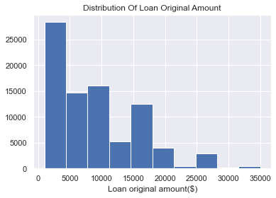

```python
# Plotting the histogram.
ax = chosen_loandata['LoanOriginalAmount'].hist()
plt.title('Distribution Of Loan Original Amount')
plt.xlabel('Loan original amount($)');
```

```python
np.log10(chosen_loandata['LoanOriginalAmount'].describe())
```

```
count    4.928667
mean     3.958250
std      3.798503
min      3.000000
25%      3.602060
50%      3.875061
75%      4.130334
max      4.544068
Name: LoanOriginalAmount, dtype: float64
```

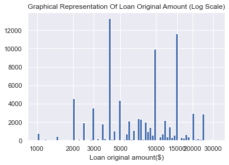

```python
#plotting histogram with log transgormation.
bins = 10** np.arange(3,4.5+0.01,0.02)
tick = [1000,2000,3000,5000,10000,15000,20000,30000]
labels=['{}'.format(x)for x in tick]
plt.hist(x='LoanOriginalAmount',data=chosen_loandata,bins=bins)
plt.xscale('log')
plt.xticks(tick,labels)
plt.title('Graphical Representation Of Loan Original Amount (Log Scale)')
plt.xlabel('Loan original amount($)');
```

The above graphical transformation shows that in this dataset most of Loan amounts are around 3k to 5 k and then 10k and mostly around 15k.

# Employment status:

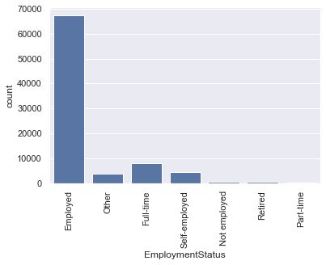

```python
sb.countplot(data = chosen_loandata, x = 'EmploymentStatus', color = 'b');
plt.xticks(rotation = 90);
```

Analysis:

# StatedMonthlyIncome:

We want to see which montlhy Income range among this dataset is most common for this we will plot StatedMonthlyIncome data.

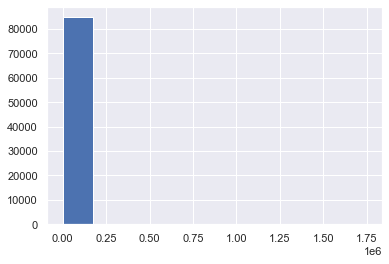

```python
plt.hist(x=chosen_loandata.StatedMonthlyIncome);
```

We should check this data column as if there are columns with no income.

```python
chosen_loandata[chosen_loandata['StatedMonthlyIncome']==0]
```

|  | index | Term | LoanStatus | BorrowerRate | BorrowerAPR | ProsperRating (Alpha) | ListingCategory (numeric) | EmploymentStatus | DelinquenciesLast7Years | StatedMonthlyIncome | TotalProsperLoans | LoanOriginalAmount | LoanOriginationDate | Recommendations | Investors |
| --- | --- | --- | --- | --- | --- | --- | --- | --- | --- | --- | --- | --- | --- | --- | --- |
| 83 | 100 | 36 | Chargedoff | 0.3134 | 0.35356 | HR | 13 | Not employed | 0.0 | 0.0 | 1.0 | 4000 | 2013-01-30 | 0 | 73 |
| 100 | 125 | 36 | Current | 0.3199 | 0.35643 | E | 7 | Not employed | 0.0 | 0.0 | 0.0 | 5000 | 2011-05-26 | 0 | 92 |
| 134 | 170 | 36 | Completed | 0.2499 | 0.28851 | D | 7 | Not employed | 0.0 | 0.0 | 0.0 | 10000 | 2012-04-17 | 0 | 161 |
| 146 | 186 | 36 | Chargedoff | 0.3177 | 0.35797 | HR | 2 | Not employed | 83.0 | 0.0 | 0.0 | 4000 | 2012-02-16 | 0 | 45 |
| 259 | 335 | 36 | Completed | 0.3177 | 0.35797 | HR | 7 | Not employed | 0.0 | 0.0 | 0.0 | 2000 | 2012-03-27 | 0 | 47 |
| ... | ... | ... | ... | ... | ... | ... | ... | ... | ... | ... | ... | ... | ... | ... | ... |
| 84604 | 113608 | 60 | Chargedoff | 0.2199 | 0.24252 | C | 1 | Employed | 0.0 | 0.0 | 1.0 | 8000 | 2011-07-29 | 0 | 182 |
| 84614 | 113622 | 36 | Chargedoff | 0.3058 | 0.34577 | E | 7 | Not employed | 0.0 | 0.0 | 0.0 | 4000 | 2012-02-03 | 0 | 45 |
| 84664 | 113682 | 60 | Chargedoff | 0.2997 | 0.32680 | D | 1 | Not employed | 0.0 | 0.0 | 0.0 | 10000 | 2012-01-17 | 0 | 1 |
| 84724 | 113761 | 60 | Current | 0.1385 | 0.16151 | A | 1 | Not employed | 0.0 | 0.0 | 1.0 | 7000 | 2012-06-05 | 0 | 9 |
| 84729 | 113766 | 36 | Current | 0.0964 | 0.12427 | A | 19 | Not employed | 0.0 | 0.0 | 1.0 | 4500 | 2012-04-23 | 0 | 71 |

693 rows × 15 columns

We have seen 693 rows/outliers which have StatedMonthlyIncome ==0 so we should drop these rows and then plot.

```python
index = chosen_loandata[chosen_loandata['StatedMonthlyIncome']==0].index
chosen_loandata.drop(index,inplace=True)
```

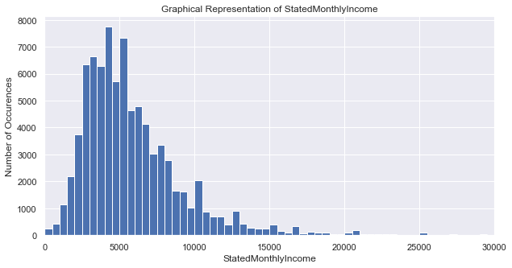

```python
plt.figure(figsize=[10,5])
bins=np.arange(0,chosen_loandata["StatedMonthlyIncome"].max()+500,500)
plt.hist(data=chosen_loandata,x="StatedMonthlyIncome",bins=bins);
plt.xlim(0,30000);
plt.xlabel("StatedMonthlyIncome")
plt.ylabel("Number of Occurences")
plt.title("Graphical Representation of StatedMonthlyIncome");
```

Analysis:

The above distribution seems to be "Skewed Right distribution"which means that one tail of the distribution considerably longer or drawn out relative to the other tail.In this case this tail is towards right.We can correct the distribution by applying Log format.

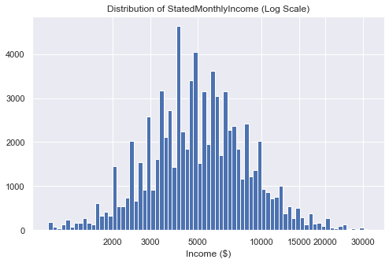

```python
# there's a long tail in the distribution, so let's put it on a log scale instead
#log_binsize = 0.025
bins = 10** np.arange(3,4.5+0.01,0.02)
tick = [2000,3000,5000,10000,15000,20000,30000]
labels=['{}'.format(x)for x in tick]
plt.figure(figsize=[8, 5])
plt.hist(data = chosen_loandata, x = 'StatedMonthlyIncome', bins = bins)
plt.xscale('log')
plt.xticks(tick,labels)
plt.xlabel('Income ($)')
plt.title('Distribution of StatedMonthlyIncome (Log Scale)')
plt.show()
```

After performing transformation we can identify that most of the data points lie between 2k to 15k.so monthlystated income lies mostly in this range.Most of Borrowers have Monthly Income range between 3k to 5k.

# Analysis of variable Prosper rating(Alpha):

# ProsperRating (Alpha):

The Prosper Rating allows this loan system to maintain consistency when evaluating each loan application. Prosper Ratings allow investors to consider a loan's level of risk because the rating represents an estimated average annualized loss rate range.

```python
chosen_loandata['ProsperRating (Alpha)'].value_counts()
```

```
C     18261
B     15525
A     14503
D     14128
E      9659
HR     6717
AA     5367
Name: ProsperRating (Alpha), dtype: int64
```

```python
chosen_loandata['ProsperRating (Alpha)'] = chosen_loandata['ProsperRating (Alpha)'].astype('category')
```

```python
chosen_loandata['ProsperRating (Alpha)'].describe()
```

```
count     84160
unique        7
top           C
freq      18261
Name: ProsperRating (Alpha), dtype: object
```

```python
# Convert ProsperRating into ordered categorical types
rate_order = ['HR','E','D','C','B','A','AA']
ordered_var = pd.api.types.CategoricalDtype(ordered = True,
                                    categories = rate_order)
chosen_loandata['ProsperRating (Alpha)'] = chosen_loandata['ProsperRating (Alpha)'].astype(ordered_var)
```

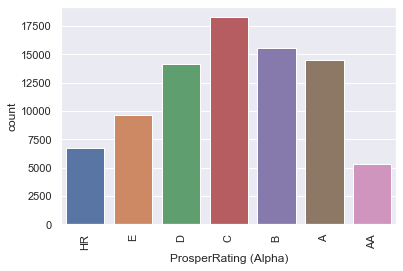

```python
#sb.countplot()Show the counts of observations in each categorical bin using bars.

#A count plot can be thought of as a histogram across a categorical, instead of quantitative, variable. The basic API and options are identical to those for barplot(), so you can compare counts across nested variables.

sb.countplot(data = chosen_loandata, x = 'ProsperRating (Alpha)');
plt.xticks(rotation = 90);
```

```python
chosen_loandata['ProsperRating (Alpha)'].value_counts()
```

```
C     18261
B     15525
A     14503
D     14128
E      9659
HR     6717
AA     5367
Name: ProsperRating (Alpha), dtype: int64
```

interpretation and Analysis of Prosper rating:

Prosper Rating Estimated Avg. Annual Loss Rate** •AA 0.00-1.99% •A 2.00–3.99% •B 4.00–5.99% •C 6.00–8.99% •D 9.00–11.99% •E 12.00–14.99% •HR ≥ 15.00%

From Above graph this is evident that most of the people in this dataset have prosper rating equals'C' whaicha according to prosper have estimated avg annual loss rate of 6 to 8.99%.

### Discuss the distribution(s) of your variable(s) of interest. Were there any unusual points? Did you need to perform any transformations?

2-Most of loans term was 36 months we will further investigate as if there is any effect of Loan Term on APR.

3-StatedMonthlyIncome was "Skewed Right distribution" so we did log transformation here to make data more meaningful.

4-LoanOriginalAmount histogram was also adjusted to make transformation more understandable.

### Of the features you investigated, were there any unusual distributions? Did you perform any operations on the data to tidy, adjust, or change the form of the data? If so, why did you do this?

1-There were Outliers in data at this point where StatedMonthlyIncome ==0 so we removed them.

2-LoanOriginal amount was also transfomed on Log scale to make clear understanding of values.

3-ProsperRating was converted to Categorical type and then countplot histogram was ploted to get better idea of ratings.

4-I also performed operations on dat for LoanStatus as to get count of values of each category of Loan and then give its representation through Matplotlib donut.

## Bivariate Exploration

To start off with, I want to look at the pairwise correlations present between features in the data.

```python
#numerical variables
biv_vars = ['LoanOriginalAmount', 'BorrowerRate', 'BorrowerAPR', 'StatedMonthlyIncome']
#categorical variables
nct_vars = ['Term', 'ProsperRating (Alpha)', 'EmploymentStatus', 'LoanStatus']
```

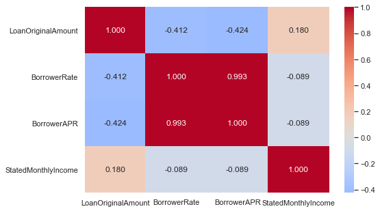

```python
# correlation plot
plt.figure(figsize = [8, 5])
sb.heatmap(chosen_loandata[biv_vars].corr(), cmap = 'coolwarm', annot = True, fmt = '.3f',
            center = 0);
```

To create a plot for all possible combinations of numerical variables we will use matrix plot.

```
loandata.shape= (84160, 15)
loandata_samp.shape= (500, 15)
```

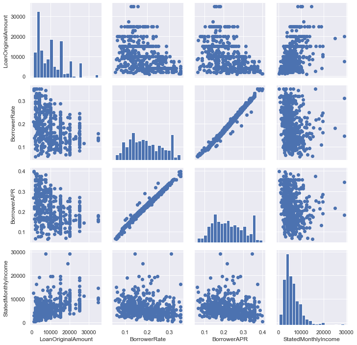

```python
# plot matrix: sample 500 loans so that plots are clearer and they render faster
print("loandata.shape=",chosen_loandata.shape)
chosen_loandata_samp = chosen_loandata.sample(n=500, replace = False)
print("loandata_samp.shape=",chosen_loandata_samp.shape)

g = sb.PairGrid(data = chosen_loandata_samp, vars = biv_vars)
g = g.map_diag(plt.hist, bins = 20);
g.map_offdiag(plt.scatter)
```

Analysis:

1-Borrowers rate(interst rate) has a positive corelation with Borrowers APR.we can see that as the interest rate rises so does the Borowers APR.

2-Loan amount and APR both are negatively corelated i.e more the loan amount lower is the Borrowers APR.

3-The loan original amount is positively correlated with the stated monthly income,that means that those borowers who have more income can lend more money or borrow more loan.(Answered our initial Hypothesis question)

# Term Vs ProsperRating subplot:

```python
sb.set_theme(style="darkgrid")
```

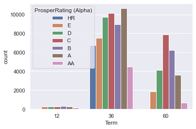

```python
sb.countplot(data = chosen_loandata, x = 'Term', hue = 'ProsperRating (Alpha)')
```

Analysis:

But we can see that there is a interaction between term and Prosper rating. Proportionally, there are more 60 month loans on B and C ratings. We can also infer from above plot that ProsperRating (Prosper rating represents an estimated average annualized loss rate range to the investor) in this loandata set is mostly for a period of 36(3 years) months loan Term.Beside that we can see that prosper rating 'A' (according to Prosper loan system,Estimated average annual loss rate of 2.00–3.99%)is highest in 36 months term.

# EmploymentStatus Vs ProsperRating(Alpha)

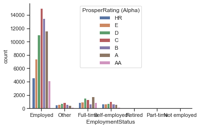

```python
custom_params = {"axes.spines.right": False, "axes.spines.top": False}
sb.set_theme(style="ticks", rc=custom_params)
sb.countplot(data = chosen_loandata, x = 'EmploymentStatus', hue = 'ProsperRating (Alpha)')

#plt.xticks(rotation=10);
```

Analysis: Most of the ratings (Prosper rating )lies with Employment status='Employed'and among these highest number of employes are with Prosper rating 'C'.

# EmploymentStatus Vs Term:

```
(array([0, 1, 2, 3, 4, 5, 6]),
 [Text(0, 0, 'Employed'),
```

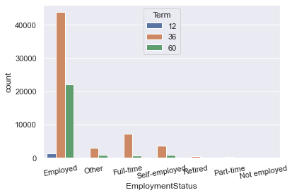

```python
sb.set_theme(style="darkgrid")
sb.countplot(data = chosen_loandata, x = 'EmploymentStatus', hue = 'Term')
plt.xticks(rotation=10)
```

Most Borrowers in this datase are Employed with loan Term of 36 months.The employment status variable does not have enough data on part-time, retired and not employed borrowers.

BorrowerRate:

Now we will see how borrower APR, stated monthly income and loan original amount correlate with the categorical variables:

# Borrower's APR vs Term:

Borrower APR vs Term: Now we will have a look on How Borrowers APR is affected by Term which is one of our initial question to be answered that Does 'Term' affects 'Borrowers APR'?

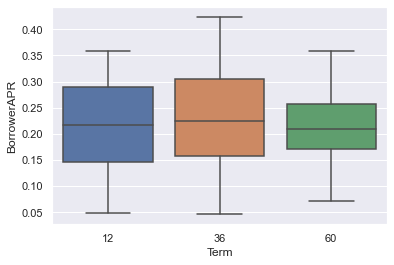

```python
fig = plt.figure()
ax2 = fig.add_subplot()
sb.boxplot(x="Term", y="BorrowerAPR", data=chosen_loandata)
```

```python
import warnings
warnings.filterwarnings('ignore')
```

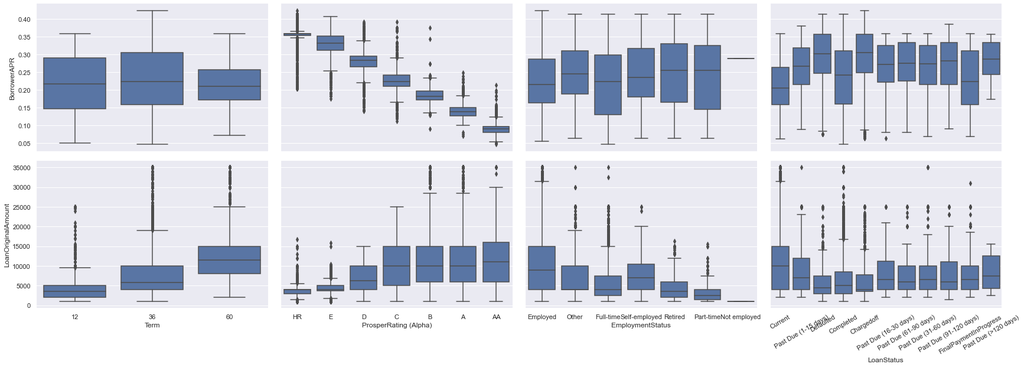

```python
# plot matrix of numeric features against categorical features.

def boxgrid(x, y, **kwargs):

    default_color = sb.color_palette()[0]
    sb.boxplot(x, y, color = default_color)

plt.figure(figsize = [10, 10])
g = sb.PairGrid(data = chosen_loandata, y_vars = ['BorrowerAPR', 'LoanOriginalAmount'],
                x_vars = nct_vars, size = 4, aspect = 1.5)
g.map(boxgrid);
plt.xticks(rotation=30);
```

Analysis:

1-Loan amount is directly related to Term that means loans with bigger amounts are for longer period of time.

2-The Borrower APR decreases with the better rating. Borrowers with the best Prosper ratings have the lowest APR. It means that the Prosper rating has a strong effect on borrower APR.

# Borrower APR vs. Prosper Rating

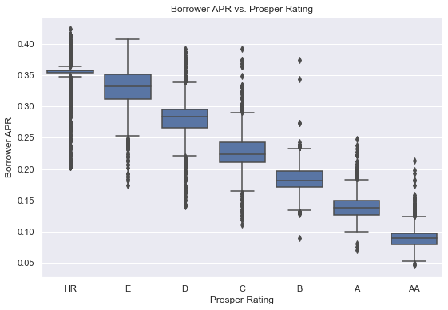

```python
plt.figure(figsize=[9,6])
default_color = sb.color_palette()[0]
sb.boxplot(data=chosen_loandata, x='ProsperRating (Alpha)', y='BorrowerAPR', color=default_color)
plt.xlabel('Prosper Rating')
plt.ylabel('Borrower APR')
plt.title('Borrower APR vs. Prosper Rating');
```

Analysis:

Borrower APR decreases with better Prosper rating and loan amount increases with better rating(AA). Interestingly, the relationship between borrower APR and loan amount turns from negative to slightly positive when the Prosper ratings are increased from HR to A or better. Those with A or AA ratings tend to borrow more money. Those borrowers with lower ratings tend to borrow less money, decreasing APR could encourage them to borrow more.

# Loan Amount Vs Borrowers Rate:

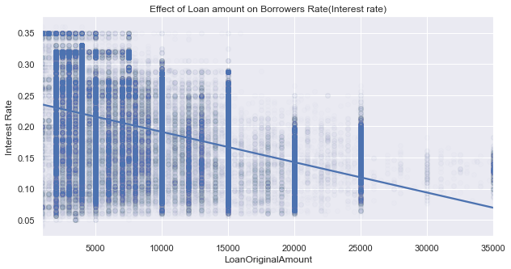

```python
plt.figure(figsize = [10, 5])
sb.set_theme(color_codes=True)
sb.regplot(data = chosen_loandata, x = 'LoanOriginalAmount', y = 'BorrowerRate', scatter_kws={'alpha':0.01});
plt.title('Effect of Loan amount on Borrowers Rate(Interest rate)')
plt.xlabel('LoanOriginalAmount')
plt.ylabel('Interest Rate');
```

Analysis:

It seems as if increase in Loan amount is making interest rate lower we can investigate it further by looking term relationship on thesed two variables.

By observing the above plot we can infer that with rising Loan amount the value of APR is decreasing.Overall, the borrower APR is negatively correlated with loan amount.

# Loanstatus vs Loan Amount:

```
(array([ 0,  1,  2,  3,  4,  5,  6,  7,  8,  9, 10]),
 [Text(0, 0, 'Current'),
```

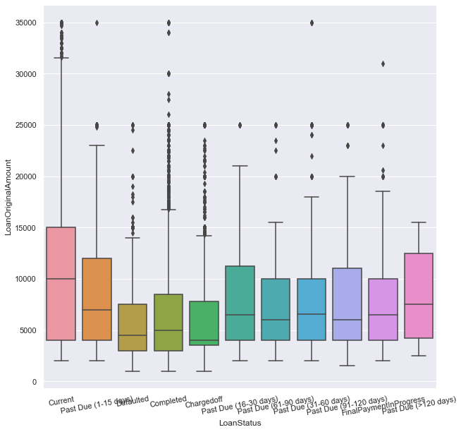

```python
plt.figure(figsize = [10, 10])
sb.boxplot(data = chosen_loandata, x = 'LoanStatus', y = 'LoanOriginalAmount');
plt.xticks(rotation=10)
```

The above graph shows Defaulted credits tend to be smaller than completed.

### Talk about some of the relationships you observed in this part of the investigation. How did the feature(s) of interest vary with other features in the dataset?

1-Borrower APR and Loan original amount are negatively correlated that means increasing loan amount has a reverse effect on APR it will decrease and vice versa.

2-It also shows that APR has a large Range area but this range is inversely propotional to loan amonunt.Range of APR decrease with the increase of loan amount.

3-Prosper Rating also has a strong effect on Borrower APR, which decreases with the better rating.

### Did you observe any interesting relationships between the other features (not the main feature(s) of interest)?

1-Loanstatus vs Loan amount: graph shows Defaulted credits tend to be smaller than completed.

2-The loan original amount is positively correlated with the stated monthly income, it makes sense since borrowers with more monthly income could loan more money.

## Multivariate Exploration

We would like to investigate here that how categorical variables are related to Borrower APR and Loan original amount.

First of all we should have a clear understanding of Prosper Rating in this system:

Every loan request is assigned a Prosper Rating through our proprietary rating system, which allows us to maintain consistency in our evaluation. The Prosper Rating is expressed as a letter grade that indicates the expected level of risk associated with a loan listing. Each letter grade corresponds to an estimated average annualized loss rate range.

# Prosper Rating VS Loanamount Vs Loanstatus

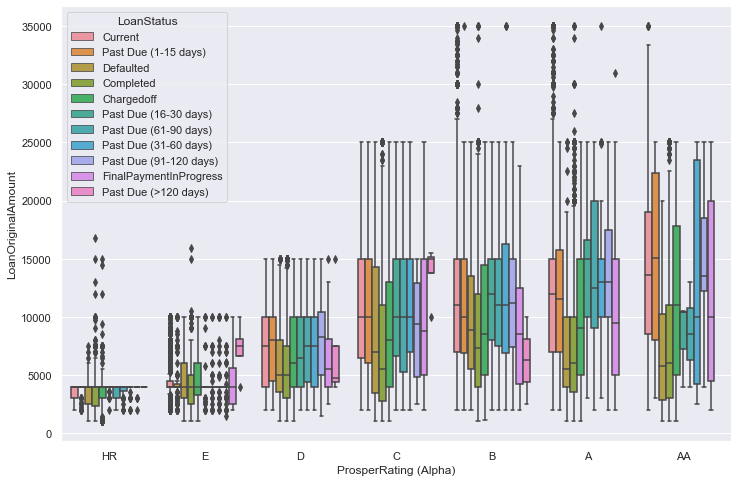

```python
plt.figure(figsize = [12, 8])
sb.boxplot(data=chosen_loandata, x='ProsperRating (Alpha)', y='LoanOriginalAmount', hue='LoanStatus');
```

For most of the loans with status equals current Prosper rating gets shifted to AA with loan maximum amount of 35000.Loan amount is higher for better prosper rating.

# Effect of ProsperRating on Borrowers APR and Loanamount:

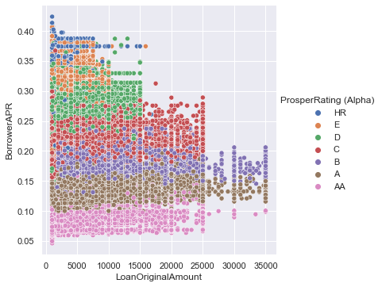

```python
sb.relplot(data=chosen_loandata, x="LoanOriginalAmount", y="BorrowerAPR", hue="ProsperRating (Alpha)"
          );
```

# Effect of Term on Borrower's APR and Loanamount:

Our initial hypothesis question will be answered here: Does Term affects APR?

```python
#1-View properties of data
chosen_loandata['LoanOriginalAmount'].describe().to_frame().T
```

|  | count | mean | std | min | 25% | 50% | 75% | max |
| --- | --- | --- | --- | --- | --- | --- | --- | --- |
| LoanOriginalAmount | 84160.0 | 9114.350832 | 6295.119549 | 1000.0 | 4000.0 | 7500.0 | 14000.0 | 35000.0 |

```python
#use floor division to create categorical variable
#generate a categorical version of the variable on the x axis

#2.From 1,Select appropriate intervals.
chosen_loandata['Loan_Amount'] =((chosen_loandata['LoanOriginalAmount']//5000)*5000)
chosen_loandata['Loan_Amount'].value_counts(). sort_index()
```

```
0        29251
5000     18428
10000    16154
15000    13262
20000     3598
25000     2854
30000      183
35000      430
Name: Loan_Amount, dtype: int64
```

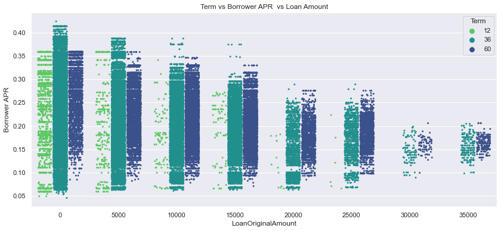

```python
plt.figure(figsize = [14, 6])
sb.stripplot(data=chosen_loandata,x='Loan_Amount',y = 'BorrowerAPR' ,hue='Term' ,palette='viridis_r' ,jitter=0.35 ,dodge=True ,size=3)

plt.title('Term vs Borrower APR  vs Loan Amount');
plt.xlabel('LoanOriginalAmount');
plt.ylabel('Borrower APR');
```

We can use the properties of the data to determine an appropriate interval. Create a new variable, with the values rounded to those intervals. Use a visualization that has the jitter option (here Seaborn's .stripplot() can be used)

# Refining The Above Plot:

```python
chosen_loandata['LoanOriginalAmount'].describe().to_frame().T
```

|  | count | mean | std | min | 25% | 50% | 75% | max |
| --- | --- | --- | --- | --- | --- | --- | --- | --- |
| LoanOriginalAmount | 84160.0 | 9114.350832 | 6295.119549 | 1000.0 | 4000.0 | 7500.0 | 14000.0 | 35000.0 |

```python
chosen_loandata['Loan_Amount'] =((chosen_loandata['LoanOriginalAmount']//1000)*1000)
```

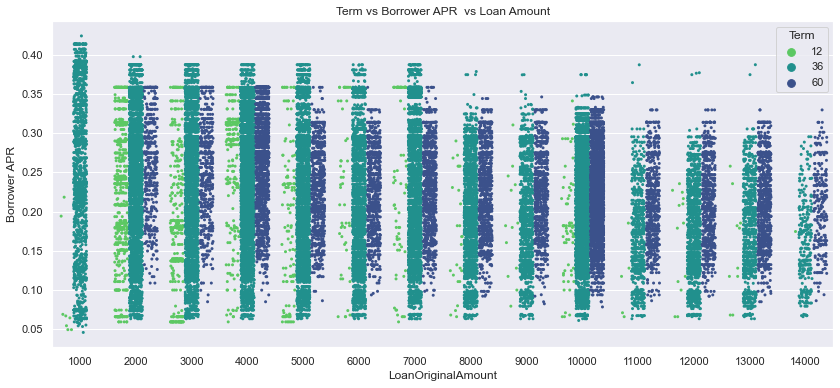

```python
plt.figure(figsize = [14, 6])
sb.stripplot(data=chosen_loandata.query('LoanOriginalAmount<=14000'),x='Loan_Amount',y = 'BorrowerAPR' ,hue='Term' ,palette='viridis_r' ,jitter=0.35 ,dodge=True ,size=3)

plt.title('Term vs Borrower APR  vs Loan Amount');
plt.xlabel('LoanOriginalAmount');
plt.ylabel('Borrower APR');
```

Analysis:

### Talk about some of the relationships you observed in this part of the investigation. Were there features that strengthened each other in terms of looking at your feature(s) of interest?

During this phase of exploration I investigated further about borrower APR and LoanOriginal amount and its impact on prosper rating.It showed following things:

1-Relationship between BorrowerAPR and LoanOriginal amount shifted from negative to slightly positive when Prosper Rating increased from HR to AA.

3-Term here seems to have a significant effect ob Borrower's APR and Loan amount.APR for 3 years lon(36 months) is higher than the APR for 5 years(60 months)loan.

## Conclusions:

The length of most of the loans are 36 months. The ratings of most of the borrowers are among D to AA.only few borrowers have HR and E ratings.

The distribution of borrowers APR looks multimodal as ot has multiple peaks.

Borrower APR is negatively corelated to Loan amount.

APR is higher than BorrowersRate(As APR in this prosper system is teh interest rate plus some additional fee/cost charged for that loan application).

I also found that the loan amount is positively correlated with the stated monthly income, it makes sense since borrowers with more monthly income could loan more money. The loan amount is also increased with the increase of loan term.